# Gigi-Brunel-M05-yardstick.qmd

Author

Gigi Brunel

Published

July 7, 2026

# 1 Exercise 9.1: Confusion Matrix and Threshold Tradeoff

## 1.1 Reading the Confusion Matrix

> Run `conf_mat(test_preds, truth = responded, estimate = .pred_class)` and use the output to answer the questions.

```
          Truth
Prediction yes  no
       yes   0   0
       no   31 569
```

1. **How many customers actually responded (“yes”) and were correctly predicted to respond? What is this cell called?**

0 customers actually responded and were accurately predicted to respond. This cell is called the True Positive because it represents customers who responded and were correctly shown by the model.

2. **How many customers actually responded but were predicted “no”? What is this cell called, and what does it cost a marketer?**

This shows that 31 customers actually responded but were predicted as “no.” This is called a False Negative. From a marketing perspective, this means these customers were not targeted even though they would have responded. As a result, the company misses potential sales.

3. **How many customers did not respond but were predicted “yes”? What is this cell called, and what does it cost a marketer?**

0 customers did not respond but were predicted as “yes.” This is called a False Positive. This model did not make any false positives.

4. **In plain English, which type of error is more costly for a direct-mail campaign with a $5 mailing cost and $50 average order value—a false positive or a false negative? Explain your reasoning.**

I think a false negative is more costly for this scenario. A false positive only wastes the $5 mailing cost, but a false negative means the business missed out on a customer who could have spent $50. Even though mailing someone who doesn’t respond costs money, losing an actual sale actually has a worse impact.

## 1.2 **Threshold Tradeoff**

> Using `test_preds`, compute `precision` and `sens` at the default 0.5 threshold. Now manually create a new `.pred_class` column using a threshold of 0.3 instead (classify as “yes” if `.pred_yes > 0.3`). Recompute both metrics. Which one increased, and why does lowering the threshold have that effect?

Precision and Sensitivity by Threshold

| threshold | .metric | .estimate |
| --- | --- | --- |
| 0.5 default | precision | NA |
| 0.5 default | sens | 0 |
| 0.3 adjusted | precision | NA |
| 0.3 adjusted | sens | 0 |

At the default threshold of 0.5, the results predicted every customer as no. As a result, precision was NA because there were no positive predictions, and sensitivity is 0 because the model failed to identify any of the customers who actually responded.

When I lowered the threshold to 0.3, the results stayed exactly the same. Precision was still NA, sensitivity remained 0 because the model still did not predict any customers as yes. Looking at the predicted probabilities, the highest value of `.pred_yes` was only 0.0714, which is well below the 0.3 threshold.

# 2 **Exercise 9.2 — ROC/AUC Interpretation and Custom `metric_set()`**

## 2.1 **Interpreting AUC**

1. **Look up the AUC value from the `roc-curve` chunk. Is it above or below 0.65 (the “usable for targeting” threshold from the callout)?**
2. **In plain English, what does an AUC of that value mean? Complete this sentence: “If we randomly pick one customer who responded and one who did not, the model assigns a higher predicted probability to the responder ____% of the time.”**
3. **The ROC curve plot shows the sensitivity/specificity tradeoff across all thresholds. At what point on the curve would you operate if your campaign budget only allows you to mail the top 10% of prospects?**

| .metric | .estimator | .estimate |
| --- | --- | --- |
| roc_auc | binary | 0.4733262 |

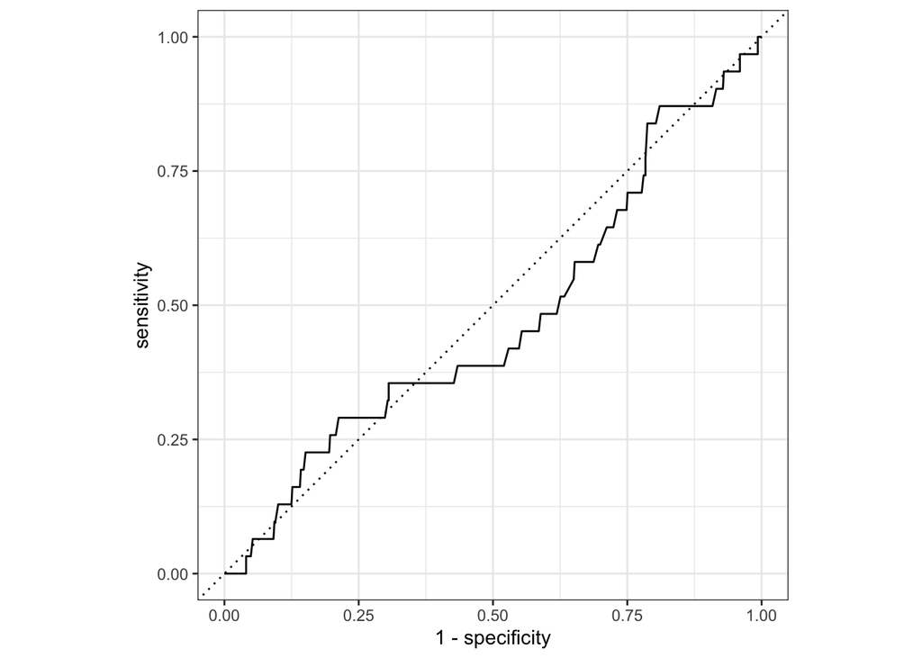

The AUC was 0.473, which is below the 0.65 benchmark, so I don’t think this model would be very useful for targeting customers. This is actually worse than random guessing because if I randomly picked a customer who responded and one who didn’t, the model would only give the responder a higher predicted probability about 47.3% of the time.

## 2.2 **Custom `metric_set()`**

> Create a `metric_set()` containing `accuracy`, `roc_auc`, `sens`, `spec`, and `f_meas`. Apply it to `test_preds`. If you had to report just **two** of these five numbers to a VP of Marketing who is unfamiliar with machine learning metrics, which would you choose and why?

| .metric | .estimator | .estimate |
| --- | --- | --- |
| accuracy | binary | 0.9483333 |
| sens | binary | 0.0000000 |
| spec | binary | 1.0000000 |
| f_meas | binary | NA |
| roc_auc | binary | 0.4733262 |

If I could only report two metrics, I would choose accuracy and AUC. Accuracy is easy for someone without a machine learning background to understand because it shows how often the model makes the correct prediction overall. However, I would also include AUC because accuracy alone can be misleading. In my results, the model had high accuracy even though it completely missed every customer who actually responded. The AUC gave a much better picture of how well the model could separate responders from non-responders, which is more useful when deciding whether the model is good enough for a marketing campaign.

# 3 **Exercise 9.3 — Regression Metric Sensitivity to Outliers**

> Add one synthetic “whale” customer to `reg_preds` with `order_value_next = 5000` and `.pred = 200` (a badly missed prediction). Recompute `rmse` and `mae`. Which metric moved more in percentage terms? What does this tell you about choosing RMSE vs. MAE for marketing data with occasional huge orders?

| .metric | .estimator | .estimate |
| --- | --- | --- |
| rmse | standard | 196.81517 |
| mae | standard | 24.06586 |

Adding the outlier increased both RMSE and MAE, but RMSE changed much more because it squares the errors before calculating the average. This makes RMSE more sensitive to large prediction errors like the whale customer. If I expected occasional customers with very large purchases, I would probably look at both metrics, but MAE gives a better idea of the model’s typical prediction error since it isn’t affected as much by extreme values.

# 4 **Exercise 9.4 — Multiclass Averaging**

> Re-run the multiclass `loyalty_tier` example using `estimator = "micro"` instead of the default macro averaging for `sens`. Also run it with `estimator = "macro_weighted"`. Compare all three numbers.
1. **Why might micro-averaging look more favorable when one class (Bronze) is much larger than the others?**

Micro averaging can look better because it gives more weight to larger classes. If most of the customers are in the Bronze tier, doing well on that group can make the overall metric look better even if the model doesn’t perform as well on the smaller groups.

2. **Which estimator would you choose if you wanted to ensure that Platinum customers — the rarest and most valuable tier — are not underrepresented in the metric? Explain your reasoning.**

I would choose macro averaging because it gives each class the same importance. The Platinum customers are evaluated the same as the larger groups instead of getting overlooked just because there are fewer of them.

3. **In a marketing context, which averaging method is most likely to give a misleadingly optimistic picture of model performance? Why?**

I think micro averaging is the most likely to give an overly optimistic view of the model because the larger classes have a bigger influence on the final score. A model could perform well overall while still doing a poor job identifying the smaller but more valuable customer groups.

Sensitivity by Averaging Method

| Averaging Method | Sensitivity |
| --- | --- |
| Macro | 0.250 |
| Micro | 0.418 |
| Macro Weighted | 0.418 |

# 5 Appendix

https://gigibrunel.github.io/W05-Reflection-on-Model-Evaluation-Ch09-/

**Repository:**

https://github.com/gigibrunel/W05-Reflection-on-Model-Evaluation-Ch09-